# Trabalho TPE II

Pacotes

```r
#########pacotes
# install.packages("tseries")
# install.packages("urca")
# install.packages("forescat")
# install.packages("rugarch")
# install.packages("forecast")
# install.packages("TSA")
# install.packages("seas")
#install.packages("seasonal")
#install.packages("seasonalview")
library(seasonal)
library(seasonalview)
library(tseries)
library(urca)
library(tseries)
library(rugarch)
library(TSA)
library(forecast)
library(seas)
```

Fazendo a Leitura da Base de Dados

```r
base <- read.csv("ipca_modelo.csv", sep = ";", stringsAsFactors = F)
base <- subset(base, base$Ano >= 2000)
base$NO.MES <- as.numeric(base$NO.MES)
ipca <- ts(base[, 4], start = c(2000, 1), frequency = 12)
```

Decomposição da Série

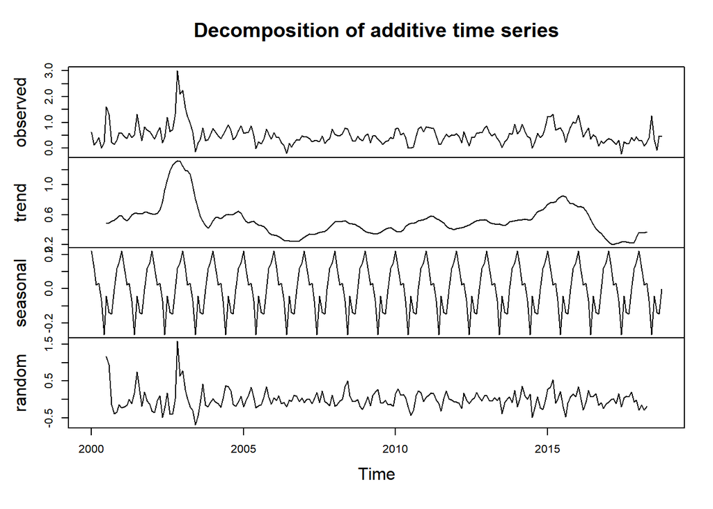

```r
x <- decompose(ipca)
plot(x)
```

Teste de Dickey & Fuller sem intercepto e sem tendência.

Rejeitamos a hipóstese nula de existência de raiz únitaria, logo temos evidências de que a série é estacionária para esse caso.

```r
modelo <-
  ur.df(ipca, type = "none", selectlags = "AIC")#Teste sem intercepto e sem tendência

summary(modelo)
```

```
##
## ###############################################
## # Augmented Dickey-Fuller Test Unit Root Test #
## ###############################################
##
## Test regression none
##
##
## Call:
## lm(formula = z.diff ~ z.lag.1 - 1 + z.diff.lag)
##
## Residuals:
##      Min       1Q   Median       3Q      Max
## -0.95029 -0.08997  0.05719  0.21505  1.90061
##
## Coefficients:
##            Estimate Std. Error t value Pr(>|t|)
## z.lag.1    -0.11469    0.03339  -3.435 0.000707 ***
## z.diff.lag -0.06843    0.06664  -1.027 0.305646
## ---
## Signif. codes:  0 '***' 0.001 '**' 0.01 '*' 0.05 '.' 0.1 ' ' 1
##
## Residual standard error: 0.3121 on 222 degrees of freedom
## Multiple R-squared:  0.06555,    Adjusted R-squared:  0.05713
## F-statistic: 7.787 on 2 and 222 DF,  p-value: 0.0005391
##
##
## Value of test-statistic is: -3.435
##
## Critical values for test statistics:
##       1pct  5pct 10pct
## tau1 -2.58 -1.95 -1.62
```

Teste de Dick-Fuller com intercepto e sem tendência.

Rejeitamos a hipóstese nula de existência de raiz únitaria, logo temos evidências de que a série é estacionária para esse caso. Vale ressaltar que o intercepto é estaticamente significante com um valor bem afastado de zero.

```r
modelo2 <-
  ur.df(ipca, type = "drift", selectlags = "AIC") #Teste com intercepto e sem tendência
summary(modelo2)
```

```
##
## ###############################################
## # Augmented Dickey-Fuller Test Unit Root Test #
## ###############################################
##
## Test regression drift
##
##
## Call:
## lm(formula = z.diff ~ z.lag.1 + 1 + z.diff.lag)
##
## Residuals:
##      Min       1Q   Median       3Q      Max
## -0.76599 -0.15216 -0.01114  0.12958  1.96879
##
## Coefficients:
##             Estimate Std. Error t value Pr(>|t|)
## (Intercept)  0.19585    0.03512   5.577 7.10e-08 ***
## z.lag.1     -0.37500    0.05622  -6.671 2.02e-10 ***
## z.diff.lag   0.06204    0.06677   0.929    0.354
## ---
## Signif. codes:  0 '***' 0.001 '**' 0.01 '*' 0.05 '.' 0.1 ' ' 1
##
## Residual standard error: 0.2929 on 221 degrees of freedom
## Multiple R-squared:  0.1808, Adjusted R-squared:  0.1734
## F-statistic: 24.39 on 2 and 221 DF,  p-value: 2.68e-10
##
##
## Value of test-statistic is: -6.6707 22.2517
##
## Critical values for test statistics:
##       1pct  5pct 10pct
## tau2 -3.46 -2.88 -2.57
## phi1  6.52  4.63  3.81
```

Teste de Dick-Fuller com intercepto e com tendência.

Rejeitamos a hipóstese nula de existência de raiz únitaria, logo temos evidências de que a série é estacionária para esse caso. Vale ressaltar que o tendência não é estaticamente significante.

```r
modelo3 <-
  ur.df(ipca, type = "trend", selectlags = "AIC") #Teste com intercepto e com tendencia
summary(modelo3)
```

```
##
## ###############################################
## # Augmented Dickey-Fuller Test Unit Root Test #
## ###############################################
##
## Test regression trend
##
##
## Call:
## lm(formula = z.diff ~ z.lag.1 + 1 + tt + z.diff.lag)
##
## Residuals:
##      Min       1Q   Median       3Q      Max
## -0.79694 -0.15116 -0.02536  0.12290  1.94262
##
## Coefficients:
##               Estimate Std. Error t value Pr(>|t|)
## (Intercept)  0.2489504  0.0530511   4.693 4.74e-06 ***
## z.lag.1     -0.3879056  0.0569452  -6.812 9.08e-11 ***
## tt          -0.0004089  0.0003066  -1.334    0.184
## z.diff.lag   0.0686196  0.0668341   1.027    0.306
## ---
## Signif. codes:  0 '***' 0.001 '**' 0.01 '*' 0.05 '.' 0.1 ' ' 1
##
## Residual standard error: 0.2924 on 220 degrees of freedom
## Multiple R-squared:  0.1874, Adjusted R-squared:  0.1763
## F-statistic: 16.91 on 3 and 220 DF,  p-value: 6.398e-10
##
##
## Value of test-statistic is: -6.8119 15.4796 23.217
##
## Critical values for test statistics:
##       1pct  5pct 10pct
## tau3 -3.99 -3.43 -3.13
## phi2  6.22  4.75  4.07
## phi3  8.43  6.49  5.47
```

Vimos que os dados não precisam ser diferenciados, pois temos evidências para dizer que a série, se encontra na forma estacionária.Logo, vamos determinar a ordem do modelo ARIMA, gerando os gráficos da FAC e FACP.

Observa-se: A FAC apresentou um decaimento das autocorrelações típicas de séries estacionárias. observa após o log 1 um decaimento rápido. Evidenciando alguns modelos como: modelo AR(1) e ARMA(1,0).

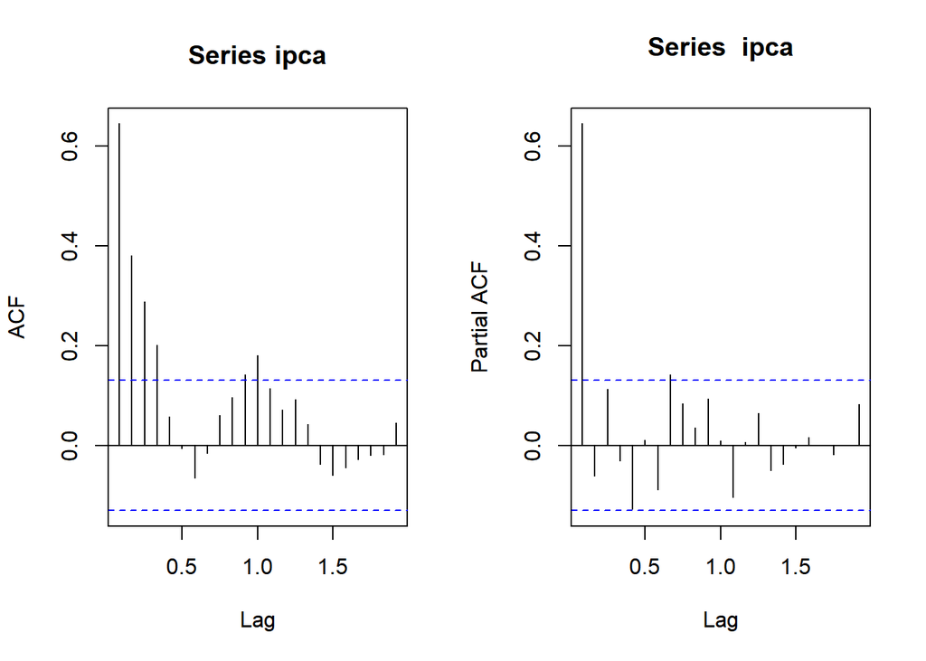

```r
par(mfrow = c(1, 2))
acf(ipca)
pacf(ipca)
```

Vamos verificar qual o melhor modelo usando os critérios de informação BIC e AIC. Nesse primeira caso vamos utilizar o modelo de 1° ordem ou seja sem diferença.

```r
##### Verificando qual o melhor medolo arima ####
modd <- mat.or.vec(9, 3)
k <- 1
for (i in 0:2) {
  for (j in 0:2) {
    modelo_arima <-
      arima(
        ipca,
        order = c(i, 0, j),
        include.mean = TRUE,
        method = "ML"
      )
    modd[k, 1] <- paste(i, 0, j)
    modd[k, 2] <- AIC(modelo_arima)
    modd[k, 3] <- BIC(modelo_arima)
    k <- k + 1
  }
}
colnames(modd) <- c("Modelo Arima", "AIC", "BIC")
modd
```

```
##       Modelo Arima AIC                BIC
##  [1,] "0 0 0"      "210.582664476955" "217.423734475499"
##  [2,] "0 0 1"      "117.102912272096" "127.364517269913"
##  [3,] "0 0 2"      "99.6956576940876" "113.377797691177"
##  [4,] "1 0 0"      "91.2330282066501" "101.494633204467"
##  [5,] "1 0 1"      "91.9029710405908" "105.58511103768"
##  [6,] "1 0 2"      "92.2022060781886" "109.30488107455"
##  [7,] "2 0 0"      "92.3602443596872" "106.042384356776"
##  [8,] "2 0 1"      "93.2093629988745" "110.312037995236"
##  [9,] "2 0 2"      "94.1934411946418" "114.716651190276"
```

Vamos verificar qual o melhor modelo usando os critérios de informação BIC e AIC. Nesse segundo caso utilizareos o modelo de 2° ordem ou seja com 1 diferença.

```r
modd <- mat.or.vec(9, 3)
k <- 1
for (j in 0:2) {
  for(m in 0:2){
    modelo_arima <-
      arima(
        ipca,
          order = c(i, 1, j),
          include.mean = TRUE,
          method = "ML")
      modd[k, 1] <- paste(i, 1, j)
      modd[k, 2] <- AIC(modelo_arima)
      modd[k, 3] <- BIC(modelo_arima)
      k <- k + 1
    }
  }
colnames(modd) <- c("Modelo Arima", "AIC", "BIC")
modd
```

```
##       Modelo Arima AIC                BIC
##  [1,] "2 1 0"      "115.216836515776" "125.465137722389"
##  [2,] "2 1 0"      "115.216836515776" "125.465137722389"
##  [3,] "2 1 0"      "115.216836515776" "125.465137722389"
##  [4,] "2 1 1"      "96.4033874652359" "110.067789074054"
##  [5,] "2 1 1"      "96.4033874652359" "110.067789074054"
##  [6,] "2 1 1"      "96.4033874652359" "110.067789074054"
##  [7,] "2 1 2"      "97.2501319926986" "114.330634003721"
##  [8,] "2 1 2"      "97.2501319926986" "114.330634003721"
##  [9,] "2 1 2"      "97.2501319926986" "114.330634003721"
```

Dentre todos os modelos, o modelo escolhido foi o modelo arima(1,0,0) segundo o critério de AIC e BIC de primeira ordem, onde apresentou-se menores valores de AIC e BIC comparado ao modelo de 2° ordem.

Modelo escolhido

```r
  modelo_arima_esc <- arima(ipca, order = c(1, 0, 0))
```

Teste Ljung-Box

Não rejeitamos a hipótese nula. Logo tesmos evidências de que os resíduos são não-autocorrelacionados

```r
Box.test(modelo_arima_esc$residuals, lag = 10, type = "Ljung-Box")
```

```
##
##  Box-Ljung test
##
## data:  modelo_arima_esc$residuals
## X-squared = 13.349, df = 10, p-value = 0.2048
```

QQplot Não podemos tirar grandes conclusões sobre o qqplot. Não há grandes discrepâncias aparentes, com Exceção das caudas .

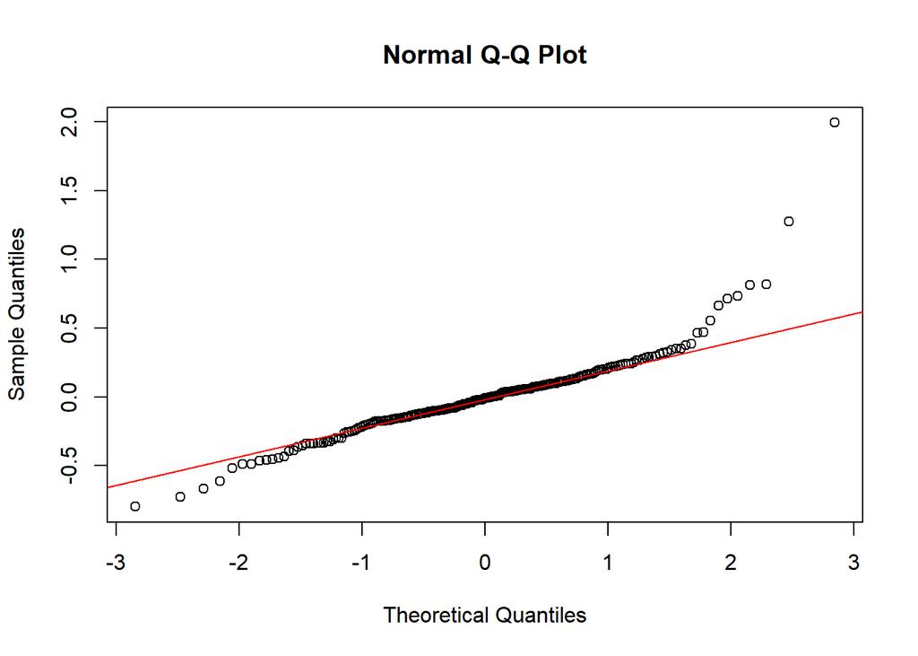

```r
qqnorm(modelo_arima_esc$residuals)
qqline(modelo_arima$residuals, col = "red")
```

Teste de normalidade de Jarque-Bera

O teste rejeita a hipótese nula de que os dados são normais logo não tem assimetria e curtose similares.

```r
jarque.bera.test(modelo_arima_esc$residuals)
```

```
##
##  Jarque Bera Test
##
## data:  modelo_arima_esc$residuals
## X-squared = 1161.9, df = 2, p-value < 2.2e-16
```

Previsão

Vamos agora fazer a previsão 2 passos a frase. Estimando dados para novembro e dezembro de 2018.

```r
previsao <- forecast(ipca, modelo_arima_esc$coef, h = 2)
previsao
```

```
##          Point Forecast Lo 51.8749697149484 Hi 51.8749697149484
## Nov 2018      0.5581620           0.3414043           0.7749197
## Dec 2018      0.6195485           0.3644094           0.8746876
##          Lo 64.2911898787822 Hi 64.2911898787822
## Nov 2018           0.2747315           0.8415926
## Dec 2018           0.2859307           0.9531663
```

Estimação pontual para meses de novembro e dezembro de 2018 com duas casas decimais.

```r
round(previsao$mean, 2)
```

```
##       Nov  Dec
## 2018 0.56 0.62
```

Gráfico da Previsão 2 passos a frente

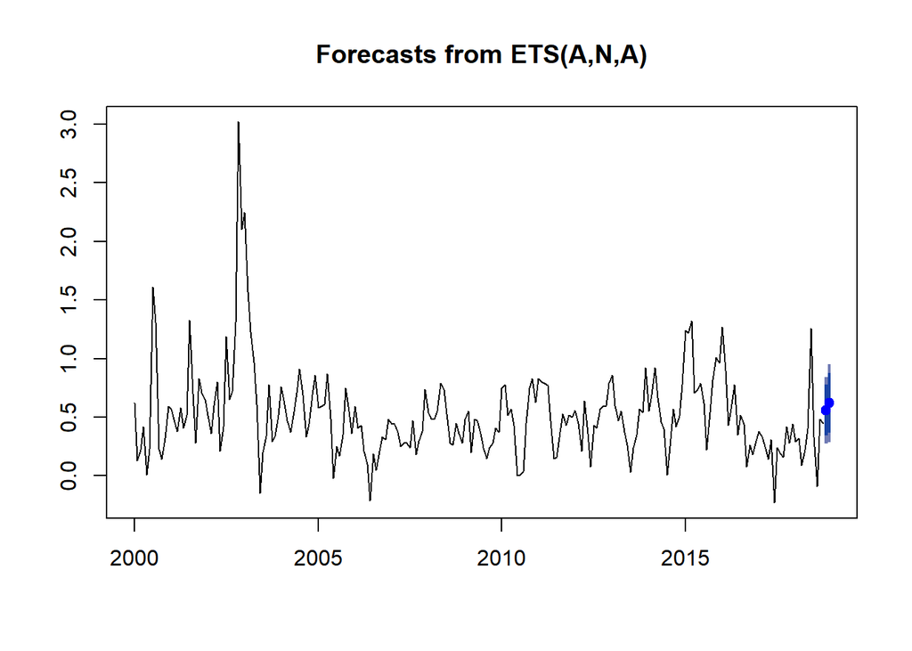

```r
plot(previsao)
```